# Self-Driving Car Engineer Nanodegree

## Project: Build a Traffic Sign Recognition Classifier

In this notebook, a template is provided for you to implement your functionality in stages, which is required to successfully complete this project. If additional code is required that cannot be included in the notebook, be sure that the Python code is successfully imported and included in your submission if necessary.

In addition to implementing code, there is a writeup to complete. The writeup should be completed in a separate file, which can be either a markdown file or a pdf document. There is a [write up template](https://github.com/udacity/CarND-Traffic-Sign-Classifier-Project/blob/master/writeup_template.md) that can be used to guide the writing process. Completing the code template and writeup template will cover all of the [rubric points](https://review.udacity.com/#!/rubrics/481/view) for this project.

The [rubric](https://review.udacity.com/#!/rubrics/481/view) contains "Stand Out Suggestions" for enhancing the project beyond the minimum requirements. The stand out suggestions are optional. If you decide to pursue the "stand out suggestions", you can include the code in this Ipython notebook and also discuss the results in the writeup file.

> **Note:** Code and Markdown cells can be executed using the **Shift + Enter** keyboard shortcut. In addition, Markdown cells can be edited by typically double-clicking the cell to enter edit mode.

## Step 0: Load The Data

```python
# Load pickled data
import pickle
import csv

# TODO: Fill this in based on where you saved the training and testing data

training_file = "data/train.p"
validation_file= "data/valid.p"
testing_file =  "data/test.p"

with open(training_file, mode='rb') as f:
    train = pickle.load(f)
with open(validation_file, mode='rb') as f:
    valid = pickle.load(f)
with open(testing_file, mode='rb') as f:
    test = pickle.load(f)

#read the csv with names.
with open('signnames.csv', 'r') as file:
    class_names=[label for label in csv.reader(file, delimiter=',')][1:] #read all but remove header


X_train, y_train = train['features'], train['labels']
X_valid, y_valid = valid['features'], valid['labels']
X_test, y_test = test['features'], test['labels']
from sklearn.utils import shuffle
X_train, y_train = shuffle(X_train, y_train)

def load_pickle(file):
    with open(file+".pckl", mode='rb') as f:
        return pickle.load(f)

def save_pickle(obj,filename):
    import os
    filename_tmp=filename
    i=0
    while(os.path.isfile(filename_tmp + ".pckl")):
        filename_tmp=filename + str(i)
        i+=1
        if i>10:
            print("too many files:o")
            break
    else:
        print("name not in use, saved as", filename_tmp + ".pckl")
        with open(filename_tmp+".pckl", mode='wb') as f:
            pickle.dump(obj, f)
```

## Step 1: Dataset Summary & Exploration

The pickled data is a dictionary with 4 key/value pairs:

- `'features'` is a 4D array containing raw pixel data of the traffic sign images, (num examples, width, height, channels).
- `'labels'` is a 1D array containing the label/class id of the traffic sign. The file `signnames.csv` contains id -> name mappings for each id.
- `'sizes'` is a list containing tuples, (width, height) representing the original width and height the image.
- `'coords'` is a list containing tuples, (x1, y1, x2, y2) representing coordinates of a bounding box around the sign in the image. **THESE COORDINATES ASSUME THE ORIGINAL IMAGE. THE PICKLED DATA CONTAINS RESIZED VERSIONS (32 by 32) OF THESE IMAGES**

Complete the basic data summary below. Use python, numpy and/or pandas methods to calculate the data summary rather than hard coding the results. For example, the [pandas shape method](http://pandas.pydata.org/pandas-docs/stable/generated/pandas.DataFrame.shape.html) might be useful for calculating some of the summary results.

### Provide a Basic Summary of the Data Set Using Python, Numpy and/or Pandas

```python
import numpy as np
import pandas as pd

np.random.seed(123) #Setting a random seed to constant, this is good when testing so that all randomness is the same
                    #on both aws and later when generating the data again(I forgot this at first, so migth give higher
                    #training accuracy)
#import random


### Replace each question mark with the appropriate value.
### Use python, pandas or numpy methods rather than hard coding the results
#choose if use grayscale or color, for testing purpose.
use_grayscale=True#False#

# TODO: Number of training examples
n_train = int(len(X_train)*5)

# TODO: Number of validation examples
n_validation = len(X_valid)

# TODO: Number of testing examples.
n_test = len(X_test)

# TODO: What's the shape of an traffic sign image?
image_shape = np.shape(X_train[0])

# TODO: How many unique classes/labels there are in the dataset.
n_classes = np.max(y_train)+1

print("Number of training examples =", len(X_train))
print("Number of training examples after adding extra =", n_train)
print("Number of Validation examples =", n_validation)
print("Number of testing examples =", n_test)
print("Image data shape =", image_shape)
print("Number of classes =", n_classes)


#For testing purpose with smaller set
if n_train < len(X_train): #delete some items(no need for random as we shuffeled already
    X_train=X_train[0:n_train]
    y_train=y_train[0:n_train]

if n_validation < len(X_valid):
    X_valid=X_valid[0:n_validation]
    y_valid=y_valid[0:n_validation]

if n_test < len(X_test):
    X_test=X_test[0:n_test]
    y_test=y_test[0:n_test]
```

```
Number of training examples = 34799
Number of training examples after adding extra = 173995
Number of Validation examples = 4410
Number of testing examples = 12630
Image data shape = (32, 32, 3)
Number of classes = 43
```

### Include an exploratory visualization of the dataset

Visualize the German Traffic Signs Dataset using the pickled file(s). This is open ended, suggestions include: plotting traffic sign images, plotting the count of each sign, etc.

The [Matplotlib](http://matplotlib.org/) [examples](http://matplotlib.org/examples/index.html) and [gallery](http://matplotlib.org/gallery.html) pages are a great resource for doing visualizations in Python.

**NOTE:** It's recommended you start with something simple first. If you wish to do more, come back to it after you've completed the rest of the sections. It can be interesting to look at the distribution of classes in the training, validation and test set. Is the distribution the same? Are there more examples of some classes than others?

```
0.762482882997574
The class no.0 is "Speed limit (20km/h)" sign
The class no.1 is "Speed limit (30km/h)" sign
The class no.2 is "Speed limit (50km/h)" sign
The class no.3 is "Speed limit (60km/h)" sign
The class no.4 is "Speed limit (70km/h)" sign
The class no.5 is "Speed limit (80km/h)" sign
The class no.6 is "End of speed limit (80km/h)" sign
The class no.7 is "Speed limit (100km/h)" sign
The class no.8 is "Speed limit (120km/h)" sign
The class no.9 is "No passing" sign
The class no.10 is "No passing for vehicles over 3.5 metric tons" sign
The class no.11 is "Right-of-way at the next intersection" sign
The class no.12 is "Priority road" sign
The class no.13 is "Yield" sign
The class no.14 is "Stop" sign
The class no.15 is "No vehicles" sign
The class no.16 is "Vehicles over 3.5 metric tons prohibited" sign
The class no.17 is "No entry" sign
The class no.18 is "General caution" sign
The class no.19 is "Dangerous curve to the left" sign
The class no.20 is "Dangerous curve to the right" sign
The class no.21 is "Double curve" sign
The class no.22 is "Bumpy road" sign
The class no.23 is "Slippery road" sign
The class no.24 is "Road narrows on the right" sign
The class no.25 is "Road work" sign
The class no.26 is "Traffic signals" sign
The class no.27 is "Pedestrians" sign
The class no.28 is "Children crossing" sign
The class no.29 is "Bicycles crossing" sign
The class no.30 is "Beware of ice/snow" sign
The class no.31 is "Wild animals crossing" sign
The class no.32 is "End of all speed and passing limits" sign
The class no.33 is "Turn right ahead" sign
The class no.34 is "Turn left ahead" sign
The class no.35 is "Ahead only" sign
The class no.36 is "Go straight or right" sign
The class no.37 is "Go straight or left" sign
The class no.38 is "Keep right" sign
The class no.39 is "Keep left" sign
The class no.40 is "Roundabout mandatory" sign
The class no.41 is "End of no passing" sign
The class no.42 is "End of no passing by vehicles over 3.5 metric tons" sign
```

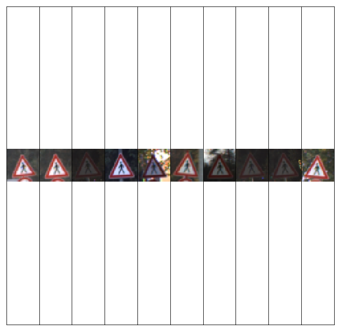

```python
### Data exploration visualization code goes here.
### Feel free to use as many code cells as needed.
import matplotlib.pyplot as plt
# Visualizations will be shown in the notebook.
%matplotlib inline
import timeit

def print_sign_all(X_data,y_data):
    #first, sort both by y_data,
    arr1inds = y_data.argsort()
    X_data = X_data[arr1inds[::1]]
    y_data = y_data[arr1inds[::1]]
    fig, axs = plt.subplots(int(np.ceil(len(X_data)/10)),10, figsize=(20,20), sharex=True, sharey=True)
    fig.subplots_adjust(hspace=0., wspace=0.0)
    axs = axs.ravel()
    for i,image in enumerate(X_data):
        axs[i].imshow(image.squeeze(), cmap="gray")


def print_sign(X_data,y_data,items_per_class=10,classes=None,location=0,squeeze=True,ordered=False):
    start_time = timeit.default_timer()
    #########################bins=np.bincount(y_data)
    cols=items_per_class
    if classes==None:
        classes=range(n_classes)
    w=20#items_per_class*2
    if items_per_class==1:
        h=10#(10*items_per_class//10)+10
    else:
        h=len(classes)*items_per_class
    #this part migth be "wrong"...
    w=10
    h=10
    if items_per_class == 1 or cols==items_per_class >10:
        cols=10
        rows=int(np.ceil(len(classes)/10) if items_per_class == 1 else np.ceil(len(classes)*(items_per_class/10)))
    else:
        cols=items_per_class
        rows=len(classes)
    fig, axs = plt.subplots(rows,cols, figsize=(w,h), sharex=True, sharey=True)
    fig.subplots_adjust(hspace=0., wspace=0.0)
    axs = axs.ravel()
    print(timeit.default_timer() - start_time)

    for i_c,c in enumerate(classes):

        indexes = np.where(y_data==c)[0] #where looks for all, how to just take first??
        #todo, this can pick same several times.. not good...
        if indexes.size:
            if ordered:
                indexes=indexes[0:items_per_class]
            else:
                indexes = np.random.choice(indexes,items_per_class,replace=False)
        for i,index in enumerate(indexes):

            pos=i_c*items_per_class+i
            if squeeze:
                image = X_data[index].squeeze()
            else:
                image = X_data[index]
            #axs[pos].set_title(bins[c])
            axs[pos].imshow(image, cmap="gray")
            axs[pos].set_xticks([])
            axs[pos].set_yticks([])




train_h=np.histogram(y_train,n_classes)
#valid_h=np.histogram(y_valid,n_classes)
#test_h=np.histogram(y_test,n_classes)
#print histogram, the optimal is that all is about the same
#plt.hist(y_train,n_classes)
#plt.show()
#plt.hist(y_valid,n_classes)
#plt.show()
#plt.hist(y_test,n_classes)
#plt.show()


##Show one random from each class #ths is extremly slow...
#A nicer way would have been to print
#"class name"
#images
#class name
#image
# etc etc.. would probably been faster too.. maybe later!
print_sign(X_train,y_train,10,classes=[27],squeeze=False) ## [0] only prints first class, i.e faster when not needed
for name in class_names:
    print("The class no.{} is \"{}\" sign".format(name[0],name[1]))
```

## Step 2: Design and Test a Model Architecture

Design and implement a deep learning model that learns to recognize traffic signs. Train and test your model on the [German Traffic Sign Dataset](http://benchmark.ini.rub.de/?section=gtsrb&subsection=dataset).

The LeNet-5 implementation shown in the classroom at the end of the CNN lesson is a solid starting point. You'll have to change the number of classes and possibly the preprocessing, but aside from that it's plug and play!

With the LeNet-5 solution from the lecture, you should expect a validation set accuracy of about 0.89. To meet specifications, the validation set accuracy will need to be at least 0.93. It is possible to get an even higher accuracy, but 0.93 is the minimum for a successful project submission.

There are various aspects to consider when thinking about this problem:

- Neural network architecture (is the network over or underfitting?)
- Play around preprocessing techniques (normalization, rgb to grayscale, etc)
- Number of examples per label (some have more than others).
- Generate fake data.

Here is an example of a [published baseline model on this problem](http://yann.lecun.com/exdb/publis/pdf/sermanet-ijcnn-11.pdf). It's not required to be familiar with the approach used in the paper but, it's good practice to try to read papers like these.

### Pre-process the Data Set (normalization, grayscale, etc.)

Minimally, the image data should be normalized so that the data has mean zero and equal variance. For image data, `(pixel - 128)/ 128` is a quick way to approximately normalize the data and can be used in this project.

Other pre-processing steps are optional. You can try different techniques to see if it improves performance.

Use the code cell (or multiple code cells, if necessary) to implement the first step of your project.

```python
import cv2
from scipy import ndimage
#tpp=X_train
#tppy=y_train
#X_train=tpp
#y_train=tppy

### Preprocess the data here. It is required to normalize the data. Other preprocessing steps could include
### converting to grayscale, etc.
### Feel free to use as many code cells as needed.


# change image so darkest is -1 and brightest is 1, then shift this so avrage is 0
# this will make dark and bright images similar even if there's a few bright pixels like glare in night
#
def gray(image):
    return cv2.cvtColor(image, cv2.COLOR_BGR2GRAY)

def normalize(image):
    minp=np.min(image)
    maxp=np.max(image)
    image=((image-minp)/(maxp-minp))*2-1
    avgp=np.average(image)
    image-=avgp
    return image

def preprocess(data,use_grayscale=True):
    images = []
    for image in data:
        if use_grayscale:
            image = gray(image)
        clahe = cv2.createCLAHE(clipLimit=4.0, tileGridSize=(4,4))
        image = clahe.apply(image)
        images.append(normalize(image))
    return np.array(images)


#Add more images, this can be done in many ways, like rotating, croping, noise etc
#we do this to make sure the classes with we examples gets more.
#we need to take care with the classes that would belong to another class when flipped, but we can also
#take advantage of this, so lets flip all left arrows and add those to rigth arrows etc etc!

#this function somethimes makes way to crazy images. so low probability
def drunkLearning(image):
    zoomx=np.random.uniform(0.4,1.4)
    zoomxy=np.random.uniform(-0.1,0.1)
    zoomy=zoomx-zoomxy
    extrapixelsx=(32-32*zoomx)/2
    extrapixelsy=(32-32*zoomy)/2
    posx=extrapixelsx+np.random.uniform(-6,6)/(zoomx*2)
    posy=extrapixelsy+np.random.uniform(-6,6)/(zoomy*2)
    skewx=np.random.uniform(-0.2,0.2)
    skewy=np.random.uniform(-0.2,0.2)
    M = np.float32([[zoomx,skewx,posx],[skewy,zoomy,posy]])
    image = cv2.warpAffine(image,M,(32,32), borderMode=cv2.BORDER_REPLICATE)
    return image

def flipToNewClass(x_data,y_data,class1,class2,num_new):
    index_class1 = np.where(y_train==class1)[0]
    index_class2 = np.where(y_train==class2)[0]
    if len(index_class1)+len(index_class2) > num_new:
        return x_data,y_data,num_new
    num_new-=len(index_class1)+len(index_class2)
    tmp_data= []#np.zeros_like(X_train)
    tmp_y= []
    for i in index_class1:
        tmp_data.append(cv2.flip(x_data[i],1))
        tmp_y.append(class2)
    for i in index_class2:
        tmp_data.append(cv2.flip(x_data[i],1))
        tmp_y.append(class1)
    x_data=np.append(x_data, np.array(tmp_data), axis=0)
    y_data=np.append(y_data, np.array(tmp_y), axis=0)
    return x_data,y_data,num_new

def change_image(image,c):
        #based on what class, we need to hardcode what kind of transformationnp
        #is allowed, this is not the nicest way...
        if c in [11,12,13,15,17,18,22,23,26,30,35] and np.random.random() < 0.3: #flip_lr, only signs that's "the same" after flip
            image=cv2.flip(image,1)
        if c in [12,15,17] and np.random.random() < 0.3: #flip_ud with 30% probability
            image=cv2.flip(image,0)
        if c in [32] and np.random.random() < 0.3:#rotate 180
            image=cv2.flip(image,0)
            image=cv2.flip(image,1)

        #rotate:
        if c in [40,15]: #+-180  #these signs can rotate 180 degree and still look the same
            degree=np.random.randint(-180,180)
        else: #+-20
            degree=np.random.randint(-20,20)

        M = cv2.getRotationMatrix2D((16,16),degree,1)
        image = cv2.warpAffine(image,M,(32,32), borderMode=cv2.BORDER_REPLICATE)
        M = np.float32([[1,0,np.random.randint(-4,4)],[0,1,np.random.randint(-4,4)]])
        image = cv2.warpAffine(image,M,(32,32), borderMode=cv2.BORDER_REPLICATE)
        if np.random.random() < 0.05:
            image=drunkLearning(image)
        return image

def addNewData(X_data,y_data,flip=True):
    num_new = n_train - len(X_data)
    if flip:
        X_data,y_data,num_new = flipToNewClass(X_data,y_data,19,20,num_new)
        X_data,y_data,num_new = flipToNewClass(X_data,y_data,33,34,num_new)
        X_data,y_data,num_new = flipToNewClass(X_data,y_data,36,37,num_new)
        X_data,y_data,num_new = flipToNewClass(X_data,y_data,38,39,num_new)

    train_h=np.bincount(y_data)
    inv_train_h=max(train_h)-train_h+num_new/(n_classes*2) ##the 1 make sure the best also get a few, change this maybe..
    #print(inv_train_h)
    class_i=np.random.choice(range(len(inv_train_h)), num_new, p=inv_train_h/sum(inv_train_h))
    count_class=np.bincount(class_i)
    tmp_data= []
    tmp_y= []

    ##Add new images
    for c,n in enumerate(count_class):
        indexes = np.where(y_data==c)[0]
        indexes = np.random.choice(indexes,n)
        for index in indexes:
            image = X_data[index]
            image=change_image(image,c)
            tmp_data.append(image)
            tmp_y.append(c)
    if len(tmp_data)>0:
        X_data=np.append(X_data, np.array(tmp_data), axis=0)
        y_data=np.append(y_data, np.array(tmp_y), axis=0)
    return X_data, y_data
```

```python
from numpy import newaxis
X_train,y_train=addNewData(X_train,y_train)

#if len(tmp_data)>0:
#    X_train=np.append(X_train, np.array(tmp_data), axis=0)
#    y_train=np.append(y_train, np.array(tmp_y), axis=0)
X_train_p = preprocess(X_train,use_grayscale)
X_valid_p = preprocess(X_valid,use_grayscale)
X_test_p = preprocess(X_test,use_grayscale)
if use_grayscale:
    X_train_p = X_train_p[..., newaxis]
    X_valid_p = X_valid_p[..., newaxis]
    X_test_p = X_test_p[..., newaxis]

print('shape after preprecess:', X_train_p.shape)
#print('Grayscale shape:', X_train_gry.shape)


#save_pickle(X_train_p,"x_train_color5x")

##shuffle the trainset
from sklearn.utils import shuffle
X_train_p,X_train,y_train = shuffle(X_train_p,X_train, y_train)
```

```
shape after preprecess: (173995, 32, 32, 1)
```

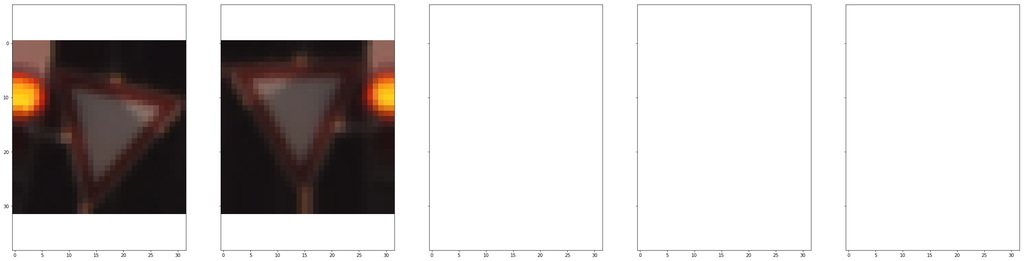

```python
#Show how  the preprocess affected the image, in the case of color, also show for each channel
#(for some reason it looks really bad to show it in color after
fig, axs = plt.subplots(1,5, figsize=(40, 10), sharex=True, sharey=True)
axs = axs.ravel()
index= np.random.randint(len(X_train))
image = X_train[index].squeeze()#normalize(X_train[index]).squeeze()
image2 = change_image(image,y_train[index])

axs[0].imshow(image, cmap="gray")
axs[1].imshow(image2, cmap="gray")
```

```
(32, 32)
-0.990948932927 1.00905106707
```

[figure not shown]

```python
#Show how  the preprocess affected the image, in the case of color, also show for each channel
#(for some reason it looks really bad to show it in color after
fig, axs = plt.subplots(1,5, figsize=(20, 10), sharex=True, sharey=True)
axs = axs.ravel()
index= np.random.randint(len(X_train_p))
image = X_train_p[index].squeeze()#normalize(X_train[index]).squeeze()
print(np.shape(image))
print(np.min(X_train_p[index]),np.max(X_train_p[index]))
axs[0].imshow((X_train[index]).squeeze(), cmap="gray")
axs[1].imshow(image, cmap="gray")
if not use_grayscale:
    axs[2].imshow(image[:,:,0], cmap="gray")
    axs[3].imshow(image[:,:,1], cmap="gray")
    axs[4].imshow(image[:,:,2], cmap="gray")
```

```
[4083 3943 3863 3920 3951 3953 4067 3941 4059 3984 3997 3940 3889 4018 4020
 4073 4126 4055 3964 4170 4216 4130 4135 4019 4100 4033 4035 4165 4095 4105
 4044 4034 4212 4031 4057 3995 4049 4190 3916 3890 4272 4111 4145]
```

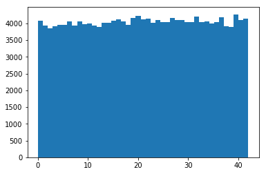

```python
#plot the histogram after adding more data, should be more equal between the classes

print(np.bincount(y_train))
plt.hist(y_train,n_classes)
plt.show()
#print_sign(X_train_p,y_train,4)
```

### Model Architecture

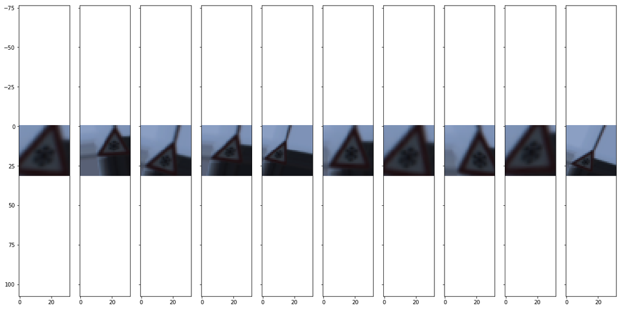

```python
#def drunkLearning(image):
 #   zoomx=np.random.uniform(0.4,1.4)
 #   zoomxy=np.random.uniform(-0.1,0.1)
 #   zoomy=zoomx-zoomxy
#    extrapixelsx=(32-32*zoomx)/2
#    extrapixelsy=(32-32*zoomy)/2
#    posx=extrapixelsx+np.random.uniform(-6,6)/(zoomx*2)
#    posy=extrapixelsy+np.random.uniform(-6,6)/(zoomy*2)
#    skewx=np.random.uniform(-0.2,0.2)
#    skewy=np.random.uniform(-0.2,0.2)
#    M = np.float32([[zoomx,skewx,posx],[skewy,zoomy,posy]])
#    image = cv2.warpAffine(image,M,(32,32), borderMode=cv2.BORDER_REPLICATE)
#    return image
#


image1=X_train[np.random.randint(len(X_train_p))]

#plt.imshow(image)
fig, axs = plt.subplots(1,10, figsize=(20, 10), sharex=True, sharey=True)
axs = axs.ravel()
for i in range(10):
    image=drunkLearning(image1)#.squeeze()
    axs[i].imshow(image, cmap="gray")
```

```python
### Define your architecture here.
### Feel free to use as many code cells as needed.
import tensorflow as tf
from tensorflow.contrib.layers import flatten

#def data_augment(images):
     #   for
    #image = tf.image.random_flip_left_right(image)
    #image = tf.image.random_brightness(image, max_delta=63)
    #image = tf.image.random_contrast(image, lower=0.2, upper=1.8)
    #image = tf.expand_dims(image, 0)
    #return image



    #NEXT LAYER IS new_height = (input_height - filter_height + 2 * P)/S + 1

def LeNet(x,keep_prob):
    # Arguments used for tf.truncated_normal, randomly defines variables for the weights and biases for each layer
    print(np.shape(x))
    mu = 0
    sigma = 0.1
    input_channels=1 if use_grayscale else 3
    #x=tf.map_fn(data_augment, x)
    #x=data_augment(x)

    # if we use color, what about using a 1x1 convlayer to turn it inte 32x32x1? Then the network will turn it to
    # grayscale itself.
    # SOLUTION: Layer 1: Convolutional. Input = 32x32x1. Output = 28x28x6.

        #Todo, try adding 1x1 conv layer.
 #   conv0_W = tf.Variable(tf.truncated_normal(shape=(1, 1, 3, 2), mean = mu, stddev = sigma))
 #   conv0_b = tf.Variable(tf.zeros(1))
  #  conv0   = tf.nn.conv2d(x, conv0_W, strides=[1, 1, 1, 1], padding='VALID',name='conv0') + conv0_b




    conv1_W = tf.Variable(tf.truncated_normal(shape=(5, 5, input_channels, 20), mean = mu, stddev = sigma))
    conv1_b = tf.Variable(tf.zeros(20))
    conv1   = tf.nn.conv2d(x, conv1_W, strides=[1, 1, 1, 1], padding='VALID',name='conv1a') + conv1_b

    # SOLUTION: Activation.
    conv1 = tf.nn.relu(conv1,name='conv1b')

    # SOLUTION: Pooling. Input = 28x28x6. Output = 14x14x6.
    conv1 = tf.nn.max_pool(conv1, ksize=[1, 2, 2, 1], strides=[1, 2, 2, 1], padding='VALID',name='conv1c')
    #conv1 = tf.nn.dropout(conv1, 0.5)



    # SOLUTION: Layer 2: Convolutional. Input = 14x14x6. Output = 10x10x16. || 12x12x24
    conv2_W = tf.Variable(tf.truncated_normal(shape=(3, 3, 20, 28), mean = mu, stddev = sigma))
    conv2_b = tf.Variable(tf.zeros(28))
    conv2   = tf.nn.conv2d(conv1, conv2_W, strides=[1, 1, 1, 1], padding='VALID',name='conv2a') + conv2_b

    # SOLUTION: Activation.
    conv2 = tf.nn.relu(conv2,name='conv2b')

    # SOLUTION: Pooling. Input = 12x12x24. Output = 5x5x16.  || 12 to 6
    conv2 = tf.nn.max_pool(conv2, ksize=[1, 2, 2, 1], strides=[1, 2, 2, 1], padding='VALID',name='conv2c')



    # SOLUTION: Layer 3: Convolutional.Input = 5x5x16.  Output = 10x10x32. || 6 to 4
    conv3_W = tf.Variable(tf.truncated_normal(shape=(3, 3, 28, 48), mean = mu, stddev = sigma))
    conv3_b = tf.Variable(tf.zeros(48))
    conv3   = tf.nn.conv2d(conv2, conv3_W, strides=[1, 1, 1, 1], padding='VALID', name='conv3a') + conv3_b

    # SOLUTION: Activation.3
    conv3 = tf.nn.relu(conv3,name='conv3b')
    #print(np.shape(conv3))
    # SOLUTION: Pooling. Input = 10x10x16. Output = 5x5x16.
    # here we have a 4x4, should be really do another maxpool to get only 2x2??? out 2x2x48
    #conv3 = tf.nn.max_pool(conv3, ksize=[1, 2, 2, 1], strides=[1, 2, 2, 1], padding='VALID')






    #Todo, try adding 1x1 conv layer.
    conv4_W = tf.Variable(tf.truncated_normal(shape=(1, 1, 48, 48), mean = mu, stddev = sigma))
    conv4_b = tf.Variable(tf.zeros(48))
    conv4   = tf.nn.conv2d(conv3, conv4_W, strides=[1, 1, 1, 1], padding='VALID',name='conv4') + conv4_b

    # SOLUTION: Flatten. Input = 5x5x16. Output = 400.
    fc0   = flatten(conv4)





    # SOLUTION: Layer 3: Fully Connected. Input = 400. Output = 120 4x4x48=768.
    fc1_W = tf.Variable(tf.truncated_normal(shape=(768, 320), mean = mu, stddev = sigma))
    fc1_b = tf.Variable(tf.zeros(320))
    fc1   = tf.matmul(fc0, fc1_W) + fc1_b

    # SOLUTION: Activation.
    fc1    = tf.nn.relu(fc1,name='fc1')
    fc1    = tf.nn.dropout(fc1,keep_prob)




    # SOLUTION: Layer 4: Fully Connected. Input = 120. Output = 84.
    fc2_W  = tf.Variable(tf.truncated_normal(shape=(320, 184), mean = mu, stddev = sigma))
    fc2_b  = tf.Variable(tf.zeros(184))
    fc2    = tf.matmul(fc1, fc2_W) + fc2_b

    # SOLUTION: Activation.
    fc2    = tf.nn.relu(fc2)
    fc2    = tf.nn.dropout(fc2,keep_prob)





        # SOLUTION: Layer 4: Fully Connected. Input = 120. Output = 84.
    fc3_W  = tf.Variable(tf.truncated_normal(shape=(184, 84), mean = mu, stddev = sigma))
    fc3_b  = tf.Variable(tf.zeros(84))
    fc3    = tf.matmul(fc2, fc3_W) + fc3_b

    # SOLUTION: Activation.
    fc3    = tf.nn.relu(fc3)
    fc3    = tf.nn.dropout(fc3,keep_prob)





    # SOLUTION: Layer 5: Fully Connected. Input = 84. Output = n_classes.
    fc4_W  = tf.Variable(tf.truncated_normal(shape=(84, n_classes), mean = mu, stddev = sigma))
    fc4_b  = tf.Variable(tf.zeros(n_classes))
    logits = tf.matmul(fc3, fc4_W) + fc4_b


    #for tensorboard
    img_hist = tf.summary.image("images", x)
    w1_hist = tf.summary.histogram("weights1", conv1_W)
    b1_hist = tf.summary.histogram("bias1", conv1_b)
    w2_hist = tf.summary.histogram("weights2", conv2_W)
    b2_hist = tf.summary.histogram("bias2", conv2_b)
    w3_hist = tf.summary.histogram("weights3", conv3_W)
    b3_hist = tf.summary.histogram("bias3", conv3_b)
    y_hist = tf.summary.histogram("y", tf.nn.softmax(logits))
    merged = tf.summary.merge_all()
    #writer = tf.summary.FileWriter("/tmp/t_logs", sess.graph_def)
    return logits
```

### Train, Validate and Test the Model

A validation set can be used to assess how well the model is performing. A low accuracy on the training and validation sets imply underfitting. A high accuracy on the training set but low accuracy on the validation set implies overfitting.

```python
EPOCHS = 10
BATCH_SIZE = 128

keep_prob = tf.placeholder(tf.float32, (None))
input_channels=1 if use_grayscale else 3
x = tf.placeholder(tf.float32, (None, 32, 32, input_channels))
y = tf.placeholder(tf.int32, (None))
one_hot_y = tf.one_hot(y, n_classes)

rate = 0.001

logits = LeNet(x,keep_prob)
cross_entropy = tf.nn.softmax_cross_entropy_with_logits(labels=one_hot_y, logits=logits)
loss_operation = tf.reduce_mean(cross_entropy)
optimizer = tf.train.AdamOptimizer(learning_rate = rate)
training_operation = optimizer.minimize(loss_operation)



correct_prediction = tf.equal(tf.argmax(logits, 1), tf.argmax(one_hot_y, 1))
accuracy_operation = tf.reduce_mean(tf.cast(correct_prediction, tf.float32))
saver = tf.train.Saver()

def evaluate(X_data, y_data):
    num_examples = len(X_data)
    total_accuracy = 0

    for offset in range(0, num_examples, BATCH_SIZE):
        batch_x, batch_y = X_data[offset:offset+BATCH_SIZE], y_data[offset:offset+BATCH_SIZE]
        accuracy = sess.run(accuracy_operation, feed_dict={x: batch_x, y: batch_y,keep_prob: 1})
        total_accuracy += (accuracy * len(batch_x))
    return total_accuracy / num_examples

def get_failing_signs(X_data, y_data):
    num_examples = len(X_data)
    total_accuracy = 0
    predicted_y=[]
    for offset in range(0, num_examples, BATCH_SIZE):
        batch_x, batch_y = X_data[offset:offset+BATCH_SIZE], y_data[offset:offset+BATCH_SIZE]
        predicted_y=np.append(predicted_y,sess.run(correct_prediction, feed_dict={x: batch_x, y: batch_y,keep_prob: 1}),axis=0)
        #predicted_y = sess.run(LeNet, feed_dict={x: batch_x,keep_prob: 1})

    return predicted_y#np.where(predicted_y==False)
```

```python
### Train your model here.
### Calculate and report the accuracy on the training and validation set.
### Once a final model architecture is selected,
### the accuracy on the test set should be calculated and reported as well.
### Feel free to use as many code cells as needed.
#error here lol, dont want to run by mistake

EPOCHS = 500
BATCH_SIZE = 512

keep_prob = tf.placeholder(tf.float32, (None))
input_channels=1 if use_grayscale else 3
x = tf.placeholder(tf.float32, (None, 32, 32, input_channels))
y = tf.placeholder(tf.int32, (None))
one_hot_y = tf.one_hot(y, n_classes)

rate = 0.001

logits = LeNet(x,keep_prob)
cross_entropy = tf.nn.softmax_cross_entropy_with_logits(labels=one_hot_y, logits=logits)
loss_operation = tf.reduce_mean(cross_entropy)
optimizer = tf.train.AdamOptimizer(learning_rate = rate)
training_operation = optimizer.minimize(loss_operation)



correct_prediction = tf.equal(tf.argmax(logits, 1), tf.argmax(one_hot_y, 1))
accuracy_operation = tf.reduce_mean(tf.cast(correct_prediction, tf.float32))
saver = tf.train.Saver()
#sess = tf.get_default_session()
def evaluate(X_data, y_data):
    num_examples = len(X_data)
    total_accuracy = 0

    for offset in range(0, num_examples, BATCH_SIZE):
        batch_x, batch_y = X_data[offset:offset+BATCH_SIZE], y_data[offset:offset+BATCH_SIZE]
        accuracy = sess.run(accuracy_operation, feed_dict={x: batch_x, y: batch_y,keep_prob: 1})
        total_accuracy += (accuracy * len(batch_x))
    return total_accuracy / num_examples

#list to hold data for plots later
train_graph_data_before=[]
train_graph_data=[]
valid_graph_data=[]
my_graph_data=[]
train_graph_data_all=[0]
valid_graph_data_all=[0]

with tf.Session() as sess:
    sess.run(tf.global_variables_initializer())
    num_examples = len(X_train_p)

    print("Training...")
    print()
    for i in range(EPOCHS):
        X_train_p, y_train = shuffle(X_train_p, y_train)
        for i_batch,offset in enumerate(range(0, num_examples, BATCH_SIZE)):
            end = offset + BATCH_SIZE
            batch_x, batch_y = X_train_p[offset:end], y_train[offset:end]

            #Comment this out to gain speed
           # if i_batch%10==0: #every 10th batch
            #    train_graph_data_before.append(evaluate(batch_x, batch_y))

            sess.run(training_operation, feed_dict={x: batch_x, y: batch_y,keep_prob: 0.5})
            #because we now have a very large training set, a lot happens every epoch
            #se lets try check accuracy several times during the epoch, will be much slower but
            #can be interesting too see what happens
            if i_batch%100==0: #every 10th batch
                train_graph_data.append(evaluate(batch_x, batch_y))
                valid_graph_data.append(evaluate(X_valid_p, y_valid))
                my_graph_data.append(evaluate(X_new_test, y_new_test))


        training_accuracy = evaluate(X_train_p, y_train)
        validation_accuracy = evaluate(X_valid_p, y_valid)
        train_graph_data_all.append(training_accuracy)
        valid_graph_data_all.append(validation_accuracy)
        print("EPOCH {} ...".format(i+1))
        print("Validation Accuracy = {:.3f}".format(validation_accuracy))
        print("Training Accuracy = {:.3f}".format(training_accuracy))
        print()
    test_accuracy = evaluate(X_test_p, y_test)
    print("test Accuracy = {:.3f}".format(test_accuracy))
    saver.save(sess, './lenet4')
    print("Model saved")

save_pickle(train_graph_data,"train_graph_data")
save_pickle(valid_graph_data,"valid_graph_data")
save_pickle(train_graph_data_all,"train_graph_data_all")
save_pickle(valid_graph_data_all,"valid_graph_data_all")
```

```
()
Training...

EPOCH 1 ...
Validation Accuracy = 0.804
Training Accuracy = 0.683

EPOCH 2 ...
Validation Accuracy = 0.888
Training Accuracy = 0.837

EPOCH 3 ...
Validation Accuracy = 0.931
Training Accuracy = 0.884

EPOCH 4 ...
Validation Accuracy = 0.948
Training Accuracy = 0.918

EPOCH 5 ...
Validation Accuracy = 0.964
Training Accuracy = 0.938

EPOCH 6 ...
Validation Accuracy = 0.962
Training Accuracy = 0.944

EPOCH 7 ...
Validation Accuracy = 0.973
Training Accuracy = 0.956

EPOCH 8 ...
Validation Accuracy = 0.973
Training Accuracy = 0.963

EPOCH 9 ...
Validation Accuracy = 0.968
Training Accuracy = 0.963

EPOCH 10 ...
```

[output cut: 1954 more lines]

```

EPOCH 499 ...
Validation Accuracy = 0.987
Training Accuracy = 0.999

EPOCH 500 ...
Validation Accuracy = 0.988
Training Accuracy = 0.999

test Accuracy = 0.972
Model saved
name not in use, saved as train_graph_data7.pckl
name not in use, saved as valid_graph_data7.pckl
name not in use, saved as train_graph_data_all7.pckl
name not in use, saved as valid_graph_data_all7.pckl
```

```
each step is: 5
```

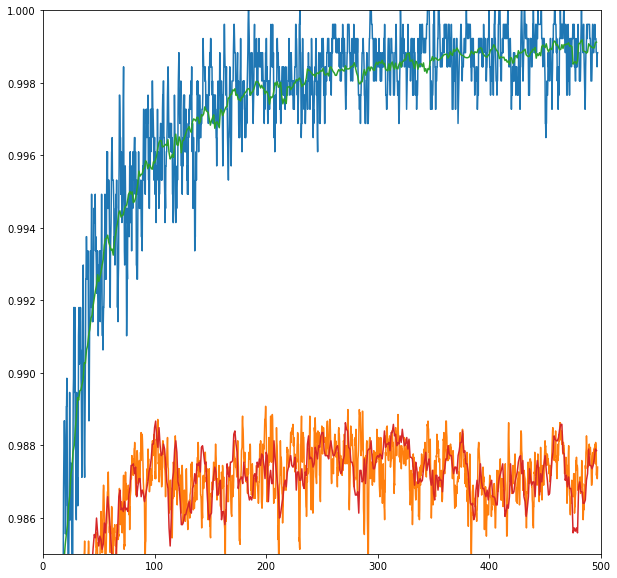

```python
import os
def running_mean(x, N=5):
    cumsum = np.cumsum(np.insert(x, 0, 0))
    return (cumsum[N:] - cumsum[:-N]) / N

p1=running_mean(train_graph_data_before)
p2=running_mean(train_graph_data)
p3=running_mean(valid_graph_data)
p4=running_mean(train_graph_data_all)
p5=running_mean(valid_graph_data_all)

fast_range=np.linspace(0,len(p5),len(p3)) #np.arange(0,len(p5),1/int(np.ceil(len(p3)/(len(p4)-1))))
p_other_range=range(len(p5))  #range(0,len(p3)+1,int(np.ceil(len(p3)/(len(p4)-1))))
print("each step is:", int(np.ceil(len(p3)/(len(p4)-1))))
plt.figure(figsize=(10,10))
plt.ylim((0.985,1))
plt.xlim((0,500))#
plt.plot(fast_range,p2,fast_range,p3,p_other_range,p4,p_other_range,p5)
#plt.plot(p2,range(len(p3)),p3,p_other_range,p4,p_other_range,p5)
#range(len(p1)),p1,range(len(p2)),



#picl=first orginal
#picl0 = low lean
#pirl1-2=??
#pickl3=maxpool at end
#pickl4=color with 1x1 conv to go from 3 to 2 (lenet2)
#pickl5=orginal 100 epoch and batch 512
#pickl6=orginal 500 epoch (lenet3)
```

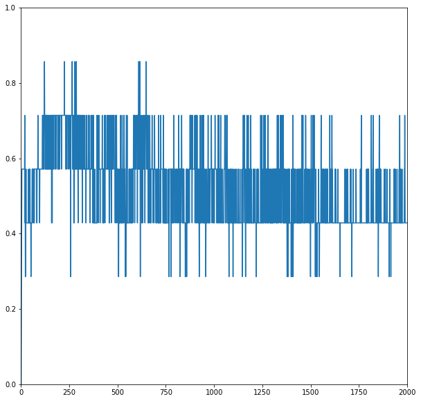

```python
#Shows how the extra images was during the training.. in the begining it actually was better.
plt.figure(figsize=(10,10))
plt.ylim((0,1))
plt.xlim((0,2000))
plt.plot(my_graph_data)
```

## Step 3: Test a Model on New Images

To give yourself more insight into how your model is working, download at least five pictures of German traffic signs from the web and use your model to predict the traffic sign type.

You may find `signnames.csv` useful as it contains mappings from the class id (integer) to the actual sign name.

### Load and Output the Images

```
0.584279376998893
```

[figure not shown]

```python
### Load the images and plot them here.
### Feel free to use as many code cells as needed.

import os

image_path = "new_test"
X_new_test = []

if os.path.isdir(image_path):
    images = [image_path+"/"+i for i in os.listdir(image_path)]
else:
    images = [image_path]

for image in images:
    tmp=cv2.imread(image)
    tmp= cv2.resize(tmp, (32, 32))
    X_new_test.append(tmp)
#X_new_test = np.asarray(X_new_test)

#print_sign(X_new_test,y_new_test,items_per_class=len(X_new_test),classes=[0],squeeze=True)
X_new_test = preprocess(X_new_test,use_grayscale)
if use_grayscale:
    X_new_test = X_new_test[..., newaxis]
y_new_test =np.array([0]*len(X_new_test))

print_sign(X_new_test,y_new_test,items_per_class=len(X_new_test),classes=[0],squeeze=True,ordered=True)
y_new_test =[22,30,28,18,24,14,2]#[30,14,2,18,22,24,28]

#22,30,28,18,24,14,2]#[24,30,14,2,18,22,24,28] true
#[18,30,14,13,0,22,18,11]
```

```python
import tensorflow as tf

with tf.Session() as sess:
    ##this can only be called once.
    nsaver = tf.train.import_meta_graph("lenet4.meta")
    nsaver.restore(sess, tf.train.latest_checkpoint('.'))
```

### Predict the Sign Type for Each Image

```python
### Run the predictions here and use the model to output the prediction for each image.
### Make sure to pre-process the images with the same pre-processing pipeline used earlier.
### Feel free to use as many code cells as needed.
import tensorflow as tf

with tf.Session() as sess:

    #nsaver = tf.train.import_meta_graph("lenet.meta")
    nsaver.restore(sess, tf.train.latest_checkpoint('.'))
    train_accuracy = evaluate(X_train_p, y_train)
    print("Train Accuracy = {}".format(train_accuracy))
    valid_accuracy = evaluate(X_valid_p, y_valid)
    print("Valid Accuracy = {}".format(valid_accuracy))

    test_accuracy = evaluate(X_test_p, y_test)
    print("Test Accuracy = {}".format(test_accuracy))

    private_images_accuracy = evaluate(X_new_test, y_new_test)
    print("My Images Accuracy = {}".format(private_images_accuracy))

    softmax = tf.nn.softmax(logits)
    probs = sess.run(softmax, feed_dict={x: X_new_test, y: y_new_test, keep_prob: 1})
    file_writer = tf.summary.FileWriter('tmptb', sess.graph)

    def testd(X_data,y_data):
        Xtmp=[]
        for i,image in enumerate(X_data):
            Xtmp.append(drunkLearning(image)[...,newaxis])
        drunk_images_accuracy = evaluate(Xtmp, y_data)
        print("Drunk Accuracy = {:.3f}".format(drunk_images_accuracy))
    X_data=X_valid_p
    y_data=y_valid
    testd(X_data,y_data)

#get_softmax(X_new_test,y_new_test)
```

```
Train Accuracy = 0.999218368343918
Valid Accuracy = 0.9879818594104308
Test Accuracy = 0.9724465562158979
My Images Accuracy = 0.4285714626312256
Drunk Accuracy = 0.758
```

```python
def getSoftmax(X_data,y_data,k=5):
    with tf.Session() as sess:

        #nsaver = tf.train.import_meta_graph("lenet.meta")
        nsaver.restore(sess, tf.train.latest_checkpoint('.'))

        softmax = tf.nn.softmax(logits)
        probs = sess.run(softmax, feed_dict={x: X_data, y: y_data, keep_prob: 1})
        return sess.run(tf.nn.top_k(tf.constant(probs), k=k))

def printSoftmax(X_data,y_data,k=5):
    softmax=np.array(getSoftmax(X_data,y_data,k))

    for i_c,c in enumerate(y_data):
        print("the sign \"{}\" was predicted as:".format(class_names[c][1]))
        for i in range(k):
            print("{:.4f} | {}".format(softmax[0,i_c,i],class_names[int(softmax[1,i_c,i])][1]))



            #print(" \"{}\" with a probability \t {:.4f}".format(class_names[int(softmax[1,i_c,i])][1],softmax[0,i_c,i]))
```

### Analyze Performance

```python
### Calculate the accuracy for these 5 new images.
### For example, if the model predicted 1 out of 5 signs correctly, it's 20% accurate on these new images.
```

### Output Top 5 Softmax Probabilities For Each Image Found on the Web

For each of the new images, print out the model's softmax probabilities to show the **certainty** of the model's predictions (limit the output to the top 5 probabilities for each image). [`tf.nn.top_k`](https://www.tensorflow.org/versions/r0.12/api_docs/python/nn.html#top_k) could prove helpful here.

The example below demonstrates how tf.nn.top_k can be used to find the top k predictions for each image.

`tf.nn.top_k` will return the values and indices (class ids) of the top k predictions. So if k=3, for each sign, it'll return the 3 largest probabilities (out of a possible 43) and the correspoding class ids.

Take this numpy array as an example. The values in the array represent predictions. The array contains softmax probabilities for five candidate images with six possible classes. `tf.nn.top_k` is used to choose the three classes with the highest probability:

```
# (5, 6) array
a = np.array([[ 0.24879643,  0.07032244,  0.12641572,  0.34763842,  0.07893497,
         0.12789202],
       [ 0.28086119,  0.27569815,  0.08594638,  0.0178669 ,  0.18063401,
         0.15899337],
       [ 0.26076848,  0.23664738,  0.08020603,  0.07001922,  0.1134371 ,
         0.23892179],
       [ 0.11943333,  0.29198961,  0.02605103,  0.26234032,  0.1351348 ,
         0.16505091],
       [ 0.09561176,  0.34396535,  0.0643941 ,  0.16240774,  0.24206137,
         0.09155967]])
```

Running it through `sess.run(tf.nn.top_k(tf.constant(a), k=3))` produces:

```
TopKV2(values=array([[ 0.34763842,  0.24879643,  0.12789202],
       [ 0.28086119,  0.27569815,  0.18063401],
       [ 0.26076848,  0.23892179,  0.23664738],
       [ 0.29198961,  0.26234032,  0.16505091],
       [ 0.34396535,  0.24206137,  0.16240774]]), indices=array([[3, 0, 5],
       [0, 1, 4],
       [0, 5, 1],
       [1, 3, 5],
       [1, 4, 3]], dtype=int32))
```

Looking just at the first row we get `[ 0.34763842, 0.24879643, 0.12789202]`, you can confirm these are the 3 largest probabilities in `a`. You'll also notice `[3, 0, 5]` are the corresponding indices.

```python
### Print out the top five softmax probabilities for the predictions on the German traffic sign images found on the web.
### Feel free to use as many code cells as needed.

printSoftmax(X_new_test,y_new_test)
```

```
the sign "Bumpy road" was predicted as:
1.0000 | Bumpy road
0.0000 | Slippery road
0.0000 | Bicycles crossing
0.0000 | Speed limit (60km/h)
0.0000 | No passing
the sign "Beware of ice/snow" was predicted as:
1.0000 | Beware of ice/snow
0.0000 | Right-of-way at the next intersection
0.0000 | Slippery road
0.0000 | Children crossing
0.0000 | Bicycles crossing
the sign "Children crossing" was predicted as:
0.9444 | Pedestrians
0.0482 | Children crossing
0.0064 | Road narrows on the right
0.0007 | Traffic signals
0.0001 | Right-of-way at the next intersection
the sign "General caution" was predicted as:
0.6116 | Speed limit (30km/h)
0.0838 | End of speed limit (80km/h)
0.0712 | Speed limit (20km/h)
0.0502 | Speed limit (80km/h)
0.0325 | Roundabout mandatory
the sign "Road narrows on the right" was predicted as:
0.3633 | Road work
0.2951 | Bicycles crossing
0.1458 | Double curve
0.0768 | Beware of ice/snow
0.0237 | Go straight or right
the sign "Stop" was predicted as:
1.0000 | Stop
0.0000 | Go straight or right
0.0000 | Turn right ahead
0.0000 | Turn left ahead
0.0000 | Speed limit (50km/h)
the sign "Speed limit (50km/h)" was predicted as:
0.9829 | Yield
0.0033 | Ahead only
0.0028 | Go straight or right
0.0019 | Turn left ahead
0.0015 | No vehicles
```

### Project Writeup

Once you have completed the code implementation, document your results in a project writeup using this [template](https://github.com/udacity/CarND-Traffic-Sign-Classifier-Project/blob/master/writeup_template.md) as a guide. The writeup can be in a markdown or pdf file.

## Step 4 (Optional): Visualize the Neural Network's State with Test Images

This Section is not required to complete but acts as an additional excersise for understaning the output of a neural network's weights. While neural networks can be a great learning device they are often referred to as a black box. We can understand what the weights of a neural network look like better by plotting their feature maps. After successfully training your neural network you can see what it's feature maps look like by plotting the output of the network's weight layers in response to a test stimuli image. From these plotted feature maps, it's possible to see what characteristics of an image the network finds interesting. For a sign, maybe the inner network feature maps react with high activation to the sign's boundary outline or to the contrast in the sign's painted symbol.

Provided for you below is the function code that allows you to get the visualization output of any tensorflow weight layer you want. The inputs to the function should be a stimuli image, one used during training or a new one you provided, and then the tensorflow variable name that represents the layer's state during the training process, for instance if you wanted to see what the LeNet lab's feature maps looked like for it's second convolutional layer you could enter conv2 as the tf_activation variable.

For an example of what feature map outputs look like, check out NVIDIA's results in their paper [End-to-End Deep Learning for Self-Driving Cars](https://devblogs.nvidia.com/parallelforall/deep-learning-self-driving-cars/) in the section Visualization of internal CNN State. NVIDIA was able to show that their network's inner weights had high activations to road boundary lines by comparing feature maps from an image with a clear path to one without. Try experimenting with a similar test to show that your trained network's weights are looking for interesting features, whether it's looking at differences in feature maps from images with or without a sign, or even what feature maps look like in a trained network vs a completely untrained one on the same sign image.

[figure not shown]

Your output should look something like this (above)

```python
### Visualize your network's feature maps here.
### Feel free to use as many code cells as needed.

# image_input: the test image being fed into the network to produce the feature maps
# tf_activation: should be a tf variable name used during your training procedure that represents the calculated state of a specific weight layer
# activation_min/max: can be used to view the activation contrast in more detail, by default matplot sets min and max to the actual min and max values of the output
# plt_num: used to plot out multiple different weight feature map sets on the same block, just extend the plt number for each new feature map entry

def outputFeatureMap(image_input, tf_activation, activation_min=-1, activation_max=-1 ,plt_num=1,length=None,per_row=10):
    # Here make sure to preprocess your image_input in a way your network expects
    # with size, normalization, ect if needed
    # image_input =
    # Note: x should be the same name as your network's tensorflow data placeholder variable
    # If you get an error tf_activation is not defined it may be having trouble accessing the variable from inside a function
    activation = tf_activation.eval(session=sess,feed_dict={x : image_input})
    featuremaps = activation.shape[3]
    if length!=None and length < featuremaps:
        featuremaps=length

    plt.figure(plt_num, figsize=(20,20))
    plt.subplots_adjust(hspace=0., wspace=0.0)
    for featuremap in range(featuremaps):
        plt.subplot(6,per_row, featuremap+1) # sets the number of feature maps to show on each row and column
        plt.title('FMap ' + str(featuremap)) # displays the feature map number
        if activation_min != -1 & activation_max != -1:
            plt.imshow(activation[0,:,:, featuremap], interpolation="nearest", vmin =activation_min, vmax=activation_max, cmap="gray")
        elif activation_max != -1:
            plt.imshow(activation[0,:,:, featuremap], interpolation="nearest", vmax=activation_max, cmap="gray")
        elif activation_min !=-1:
            plt.imshow(activation[0,:,:, featuremap], interpolation="nearest", vmin=activation_min, cmap="gray")
        else:
            plt.imshow(activation[0,:,:, featuremap], interpolation="nearest", cmap="gray")
```

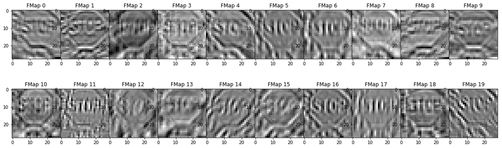

[figure not shown]

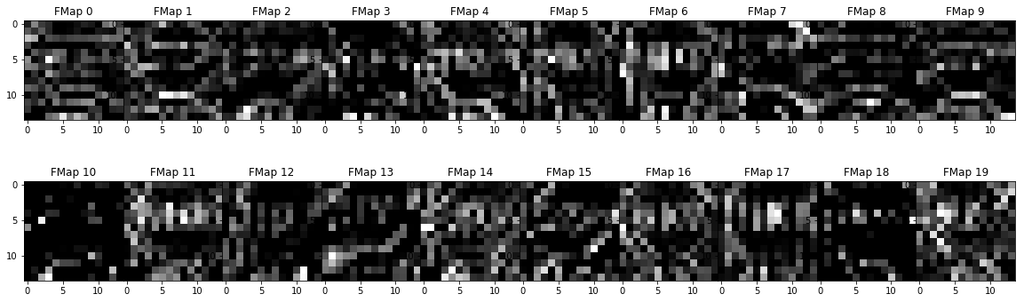

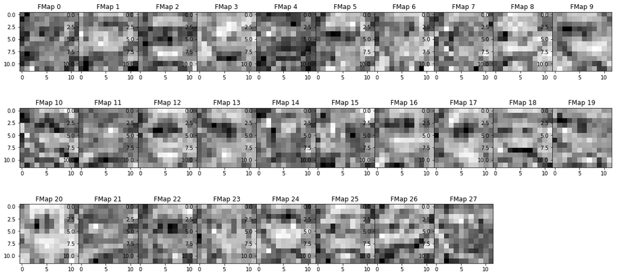

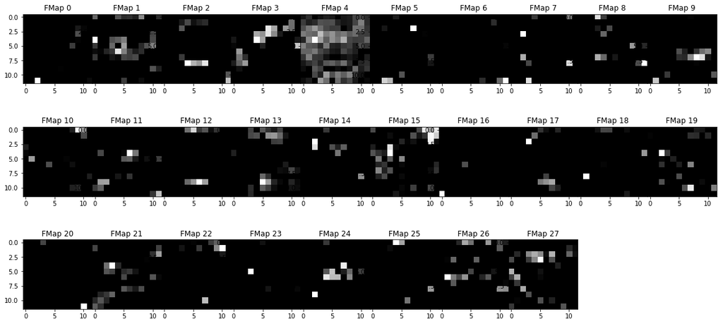

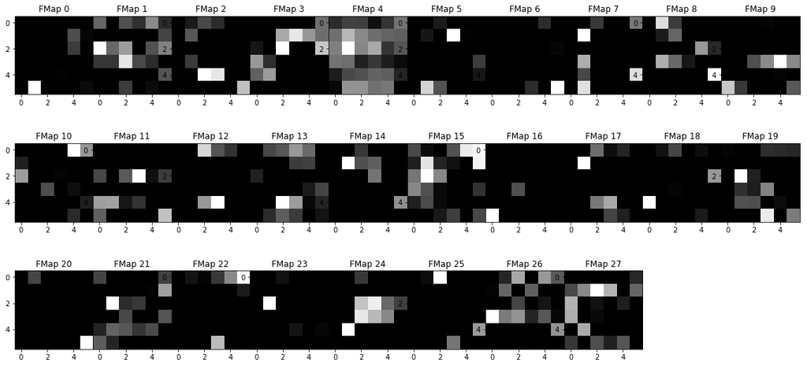

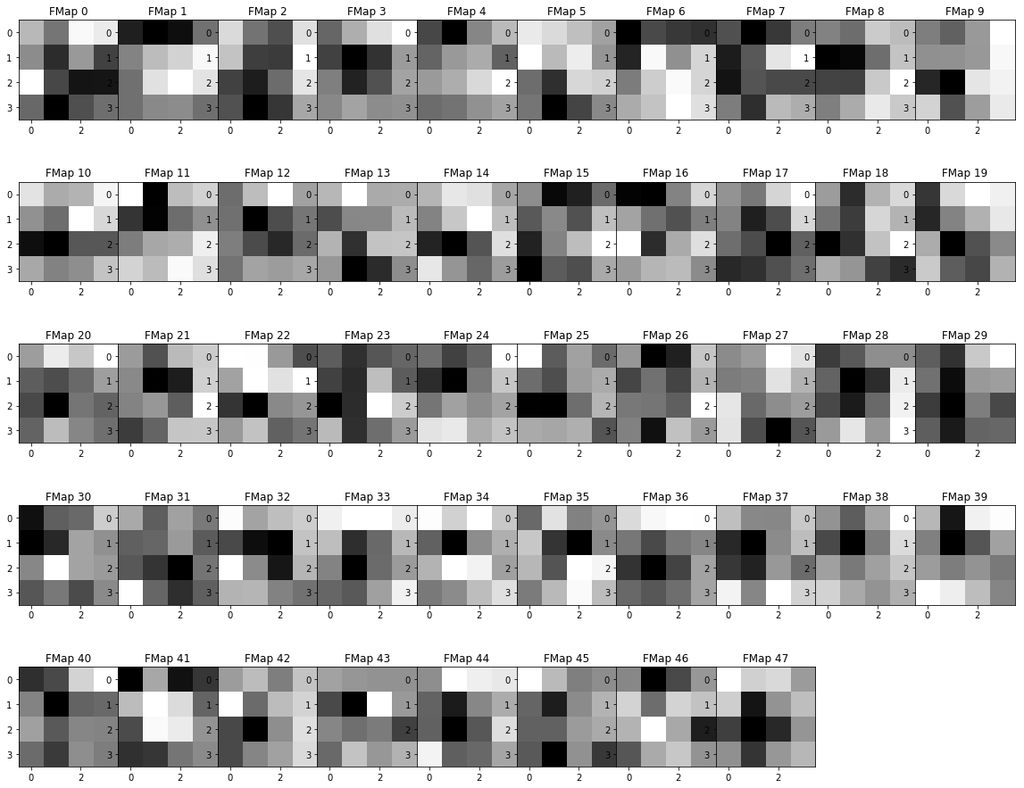

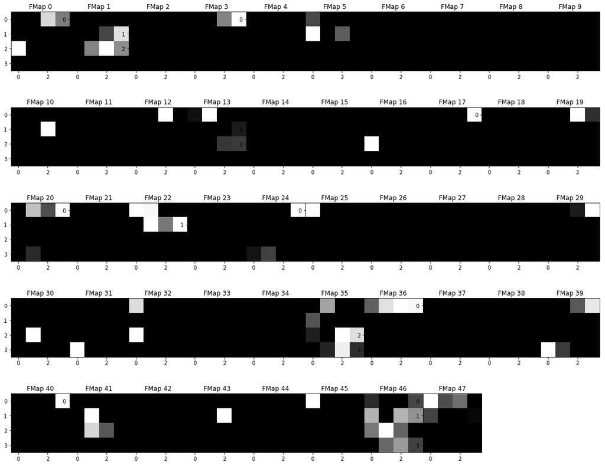

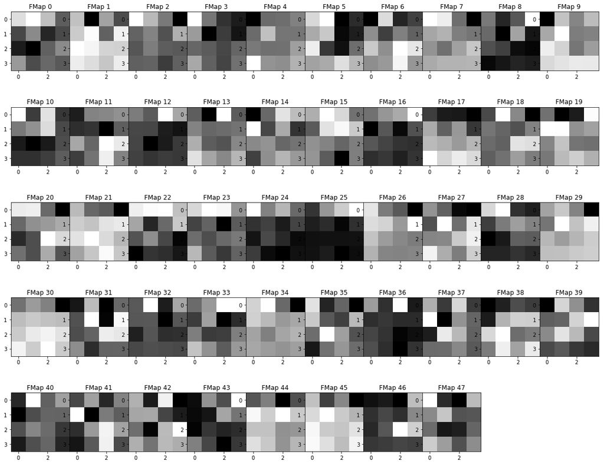

```python
image_input= X_new_test[5][newaxis,... ]

with tf.Session() as sess:
    saver.restore(sess, tf.train.latest_checkpoint('.'))

    conv1a = sess.graph.get_tensor_by_name('conv1a:0')
    outputFeatureMap(image_input, conv1a, activation_min=-1, activation_max=-1 ,plt_num=1)
    conv1b = sess.graph.get_tensor_by_name('conv1b:0')
    outputFeatureMap(image_input, conv1b, activation_min=-1, activation_max=-1 ,plt_num=2)
    conv1c = sess.graph.get_tensor_by_name('conv1c:0')
    outputFeatureMap(image_input, conv1c, activation_min=-1, activation_max=-1 ,plt_num=3)

    conv2a = sess.graph.get_tensor_by_name('conv2a:0')
    outputFeatureMap(image_input, conv2a, activation_min=-1, activation_max=-1 ,plt_num=4)
    conv2b = sess.graph.get_tensor_by_name('conv2b:0')
    outputFeatureMap(image_input, conv2b, activation_min=-1, activation_max=-1 ,plt_num=5)
    conv2c = sess.graph.get_tensor_by_name('conv2c:0')
    outputFeatureMap(image_input, conv2c, activation_min=-1, activation_max=-1 ,plt_num=6)

    conv3a = sess.graph.get_tensor_by_name('conv3a:0')
    outputFeatureMap(image_input, conv3a, activation_min=-1, activation_max=-1 ,plt_num=7)
    conv3b = sess.graph.get_tensor_by_name('conv3b:0')
    outputFeatureMap(image_input, conv3b, activation_min=-1, activation_max=-1 ,plt_num=8)

    conv4 = sess.graph.get_tensor_by_name('conv4:0')
    outputFeatureMap(image_input, conv4, activation_min=-1, activation_max=-1 ,plt_num=9)
```

```
INFO:tensorflow:Restoring parameters from ./lenet
INFO:tensorflow:Restoring parameters from ./lenet
```

```
TopKV2(values=array([[  9.98825610e-01,   1.17442233e-03,   6.86270138e-12],
       [  1.00000000e+00,   7.17326509e-09,   2.23561270e-16],
       [  9.79132056e-01,   2.08679978e-02,   7.23658702e-11],
       [  9.99996305e-01,   3.68347560e-06,   6.56946340e-13]], dtype=float32), indices=array([[30, 11, 21],
       [30, 11, 25],
       [11, 30, 21],
       [11, 30, 21]], dtype=int32))
```

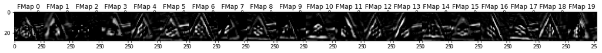

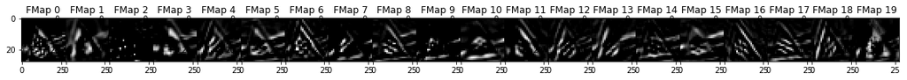

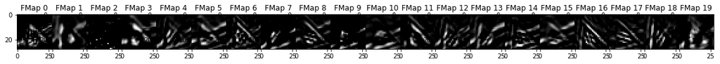

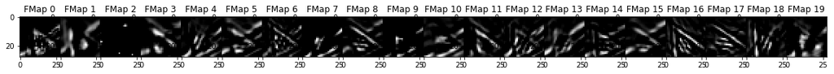

```python
#Now we can see how the network can "see" something, but how can it generalize? how can a new slighly rotated
#be the same as the orginal? well let's find out by rotation 1 degree, and show feature map for each, how will they differ?
aindex=0;
anum_rotations=3
aimage= X_new_test[aindex]
#y=[[y_new_test[index]]*num_rotations]
ay=[0,0,0]
aM = cv2.getRotationMatrix2D((16,16),10,1)#Rotade by 1 degree
aimages=aimage[newaxis,...]
atmp=aimage
for i in range(anum_rotations):
    atmp=cv2.warpAffine(atmp,aM,(32,32), borderMode=cv2.BORDER_REPLICATE)
    aimage=atmp[newaxis,...,newaxis]
    aimages=np.append(aimages, np.array(aimage), axis=0)

with tf.Session() as sess:
    saver.restore(sess, tf.train.latest_checkpoint('.'))
    for i,oimage in enumerate(aimages):
        aconv = sess.graph.get_tensor_by_name('conv1b:0')
        outputFeatureMap(oimage[newaxis,...], aconv, activation_min=-1, activation_max=-1 ,plt_num=i+1, length=None,per_row=20)

getSoftmax(aimages,ay,3)
```

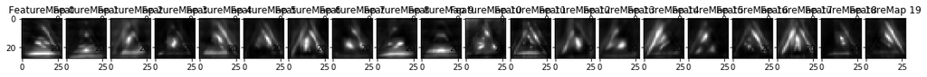

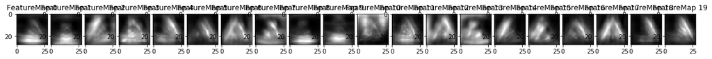

```python
#can we create an avrage map of the signs?
#Another thing is to look what images makes the neurons activate the most, like in https://arxiv.org/pdf/1311.2524.pdf
featuremaps=20
avrage_active_neurons=np.zeros((n_classes,featuremaps))

with tf.Session() as sess:
    saver.restore(sess, tf.train.latest_checkpoint('.'))
    tf_activation=sess.graph.get_tensor_by_name('conv1b:0')
    for c in [11,30]:#range(n_classes):
        indexes = np.where(y_train==c)[0]
        images = X_train_p[indexes]
        activation=[]

        for i,image in enumerate(images):
            activation.append(tf_activation.eval(session=sess,feed_dict={x : image[newaxis,...]}))
        avgc=np.average(activation,axis=0)
        #is there a better way to average over 2 axis?
        avrage_active_neurons[c,:]=np.average(np.average(avgc,axis=1),axis=1)[0,:]

        plt.figure(c, figsize=(20,20))
        plt.subplots_adjust(hspace=0., wspace=0.1)
        for featuremap in range(featuremaps):
            plt.subplot(6,20, featuremap+1) # sets the number of feature maps to show on each row and column
            plt.title('FeatureMap ' + str(featuremap)) # displays the feature map number
            plt.imshow(avgc[0,:,:,featuremap], cmap="gray")


        #print(c)
        #print(avrage_active_neurons[c,:])
```

```python
class_neurons=np.argmax(avrage_active_neurons,axis=0)
print(np.bincount(class_neurons))
print(np.argmax(avrage_active_neurons,axis=0))
```

```
[ 0  0  0  0  0  0  0  0  0  0  0 13  0  0  0  0  0  0  0  0  0  0  0  0  0
  0  0  0  0  0  7]
[11 11 30 30 11 11 11 11 30 30 30 11 30 11 11 11 11 11 30 11]
```

[output not shown]

```python
#make it work, just for fun...
def TB(cleanup=False):
    import webbrowser
    webbrowser.open('http://127.0.0.1:6006')
    !tensorboard --logdir="tmptb"

    if cleanup:
        !rm -R logs/

TB(1)
```

[output not shown]

```python
#Another thing to check is how good each class does,
def class_accuracy(X_data,y_data):
    with tf.Session() as sess:
        saver.restore(sess, tf.train.latest_checkpoint('.'))
        accuracy_class=np.zeros((n_classes,2))
        for c in range(n_classes):
            indexes=np.where(y_data==c)
            accuracy_class[c]=[c,evaluate(X_data[indexes], y_data[indexes])]
        return(accuracy_class)

with tf.Session() as sess:
    saver.restore(sess, tf.train.latest_checkpoint('.'))
    print(class_accuracy(X_valid_p,y_valid))
```

```
[[  0.           1.        ]
 [  1.           0.99166662]
 [  2.           0.99583334]
 [  3.           0.9600001 ]
 [  4.           1.        ]
 [  5.           0.98571432]
 [  6.           1.        ]
 [  7.           1.00000012]
 [  8.           0.9866668 ]
 [  9.           1.00000012]
 [ 10.           1.        ]
 [ 11.           1.00000012]
 [ 12.           1.        ]
 [ 13.           0.99583334]
 [ 14.           1.        ]
 [ 15.           1.        ]
 [ 16.           0.58333337]
 [ 17.           1.00000012]
 [ 18.           0.99166667]
 [ 19.           1.        ]
 [ 20.           0.91666669]
 [ 21.           0.91666675]
 [ 22.           1.        ]
 [ 23.           0.98333341]
 [ 24.           1.        ]
 [ 25.           1.00000012]
 [ 26.           1.        ]
 [ 27.           0.9666667 ]
 [ 28.           1.        ]
 [ 29.           1.        ]
 [ 30.           1.        ]
 [ 31.           1.        ]
 [ 32.           1.        ]
 [ 33.           1.        ]
 [ 34.           1.        ]
 [ 35.           1.00000012]
 [ 36.           1.        ]
 [ 37.           1.        ]
 [ 38.           1.        ]
 [ 39.           1.        ]
 [ 40.           1.        ]
 [ 41.           1.        ]
 [ 42.           1.        ]]
```

```python
def print_failed_signs(X_data,y_data,c=range(n_classes)):
    with tf.Session() as sess:
        saver.restore(sess, tf.train.latest_checkpoint('.'))
        correct = get_failing_signs(X_data, y_data)

    wrong_indexes=np.where(correct==False)
    len(wrong_indexes[0])
    #print_sign_all(X_valid_p[wrong_indexes[0]],y_valid[wrong_indexes[0]])
    for index in wrong_indexes[0]:
        if y_data[index] in c:
            print("------------------------")
            #print(class_names[y_valid[index]])
            plt.imshow(X_data[index].squeeze(),cmap="gray")
            plt.show()
            print(y_data[index])
            printSoftmax(X_data[index][newaxis,...],y_data[index][newaxis,...],k=5)

with tf.Session() as sess:
    saver.restore(sess, tf.train.latest_checkpoint('.'))
    print_failed_signs(X_test_p,y_test,[27])
```

[output not shown]